# Tarea 4.

## Metodos no supervisados

### Estudiante:

- Brian Durán

## Ejercicios

Librerias

```r
library("ggplot2")
library(GGally)
library(reshape2)
library(visdat)
library(factoextra)
library(dplyr)
```

1. Desarolle el Análisis del Problema

Se realizará una revisión de un conjunto de datos que continue el gasto anual en unidades monetarios de los clientes de un distribuidor mayorista. El propósito del análisis es determinar en cuales categorias de productos se encuentra el mayor consumo, además de observar cualquier relación que exista entre las variables. El principal método a utilizar para esto será el algoritmo de agrupamiento K-means.

Fuente del dataset: https://archive.ics.uci.edu/ml/datasets/wholesale+customers

2. Cargue el archivo wholesale customers data.csv en una variable

```r
wholesale <- read.csv("wholesale.csv")
```

3. Desarolle el Entendimiento de los Datos

### Información sobre las variables

El conjunto de datos continue 440 filas y 8 variables en total, cuya definición es la siguiente:

1. FRESH: gasto anual (m.u.) en productos frescos (Continuo);
2. MILK: gasto anual (m.u.) en productos lácteos (Continuo);
3. GROCERY: gasto anual (m.u.) en productos comestibles (Continuo);
4. FROZEN: gasto anual (m.u.) en productos congelados (Continuo)
5. DETERGENTS_PAPER: gasto anual (m.u.) en detergentes y productos de papel (Continuo)
6. DELICASSEN: gasto anual (m.u.) en productos delicatessen (Continuo);
7. CANAL: Canal de clientes - Horeca (Hotel / Restaurante / Café) o Canal minorista (Nominal)
8. REGION: Región de clientes - Lisnon, Oporto u Otro (Nominal)

```r
head(wholesale)
```

```
##   Channel Region Fresh Milk Grocery Frozen Detergents_Paper Delicassen
## 1       2      3 12669 9656    7561    214             2674       1338
## 2       2      3  7057 9810    9568   1762             3293       1776
## 3       2      3  6353 8808    7684   2405             3516       7844
## 4       1      3 13265 1196    4221   6404              507       1788
## 5       2      3 22615 5410    7198   3915             1777       5185
## 6       2      3  9413 8259    5126    666             1795       1451
```

Estadísticas descriptivas:

```r
summary(wholesale[, 3:8])
```

```
##      Fresh             Milk          Grocery          Frozen
##  Min.   :     3   Min.   :   55   Min.   :    3   Min.   :   25.0
##  1st Qu.:  3128   1st Qu.: 1533   1st Qu.: 2153   1st Qu.:  742.2
##  Median :  8504   Median : 3627   Median : 4756   Median : 1526.0
##  Mean   : 12000   Mean   : 5796   Mean   : 7951   Mean   : 3071.9
##  3rd Qu.: 16934   3rd Qu.: 7190   3rd Qu.:10656   3rd Qu.: 3554.2
##  Max.   :112151   Max.   :73498   Max.   :92780   Max.   :60869.0
##  Detergents_Paper    Delicassen
##  Min.   :    3.0   Min.   :    3.0
##  1st Qu.:  256.8   1st Qu.:  408.2
##  Median :  816.5   Median :  965.5
##  Mean   : 2881.5   Mean   : 1524.9
##  3rd Qu.: 3922.0   3rd Qu.: 1820.2
##  Max.   :40827.0   Max.   :47943.0
```

Por último, no existen valores faltantes dentro de las variables y las mismas solo poseen datos númericos.

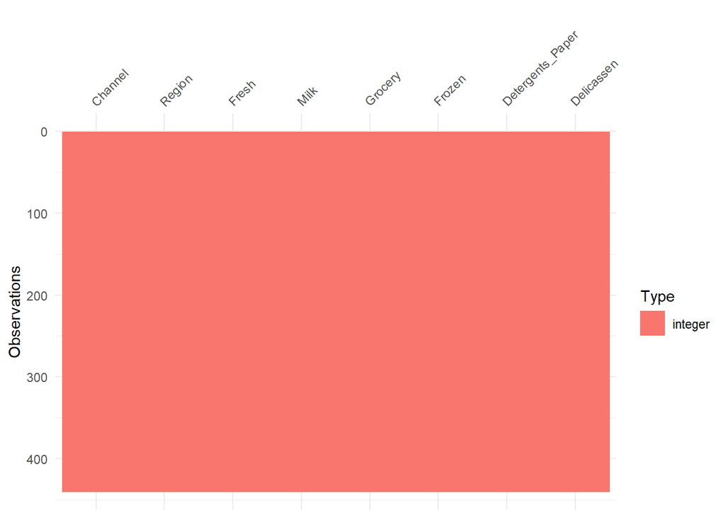

```r
vis_dat(wholesale)
```

4. Utilizando barplot cree un gráfico de los atributos del dataset, observe las correlaciones entre atributos

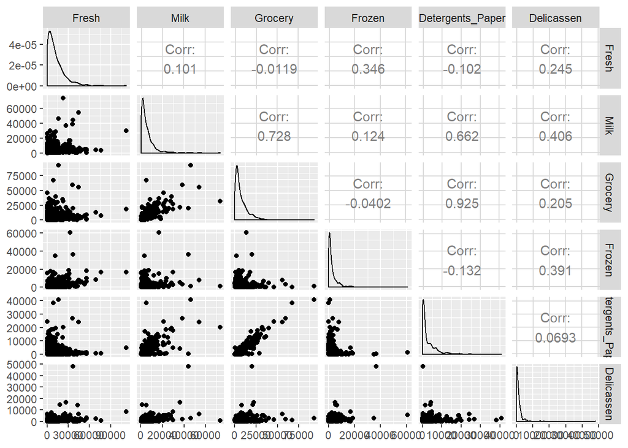

```r
ggpairs(wholesale[3:8])
```

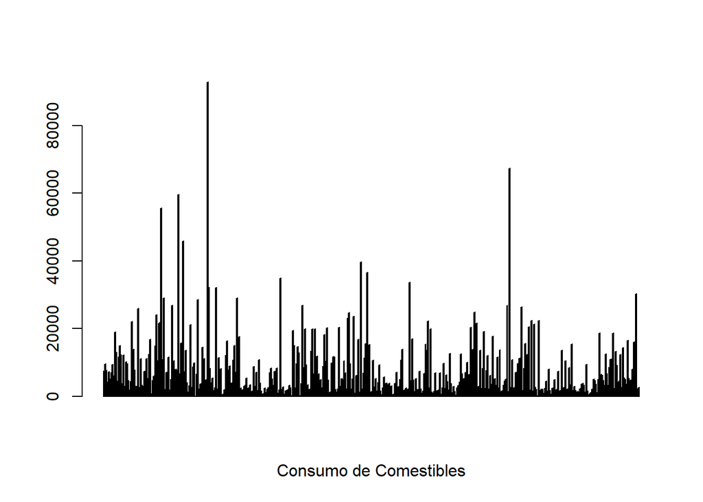

```r
barplot(wholesale$Grocery, xlab = "Consumo de Comestibles")
```

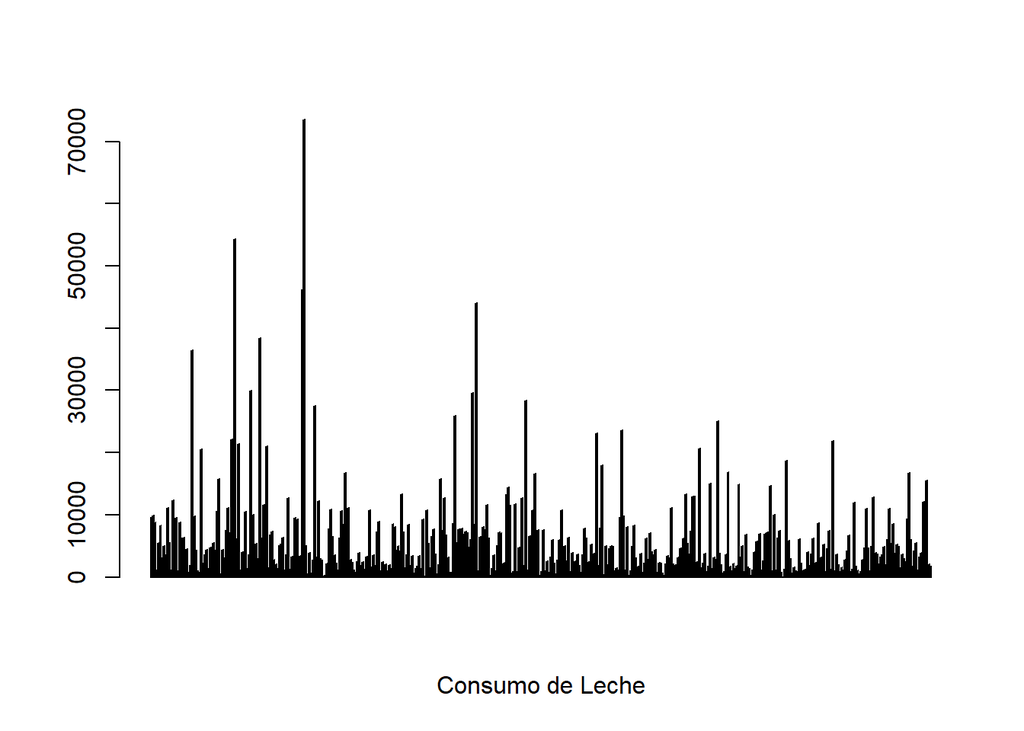

```r
barplot(wholesale$Milk, xlab = "Consumo de Leche")
```

5. Explique el siguiente gráfico

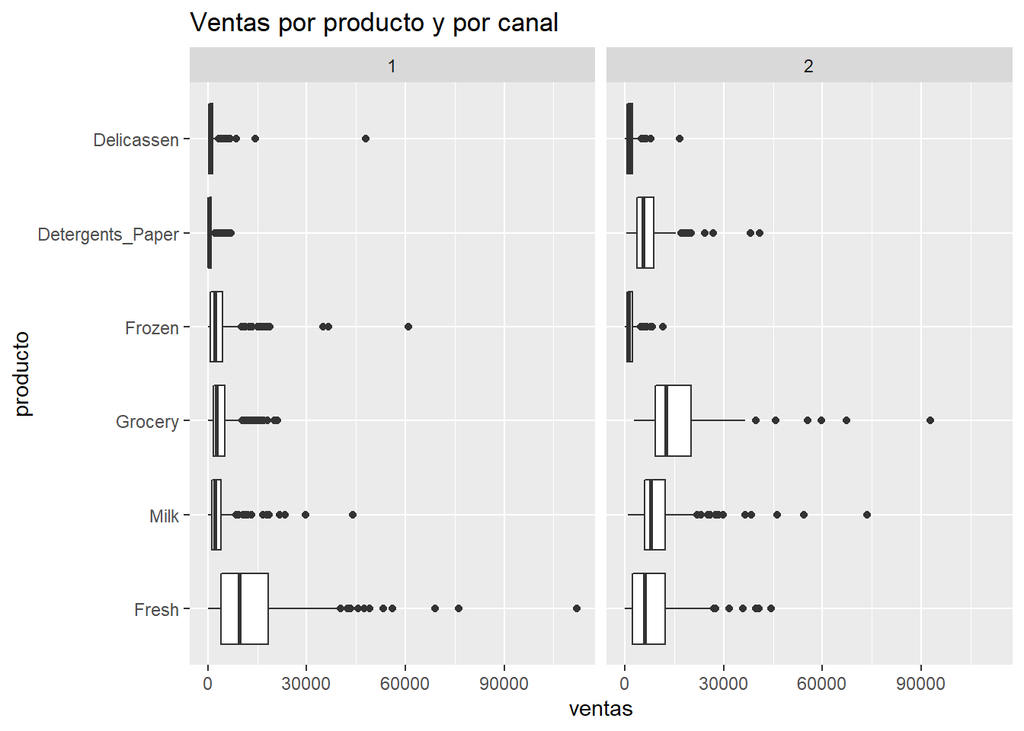

```r
melted_wholesale <- melt(data=wholesale, id.vars = c("Channel", "Region"))

#Gráfico
bxplt <- ggplot(data = melted_wholesale, aes(x= variable, y = value))
bxplt <- bxplt + geom_boxplot()
bxplt <- bxplt + facet_wrap(~Channel)
bxplt <- bxplt + coord_flip()
bxplt <- bxplt + labs(x = "producto", y  = "ventas")
bxplt <- bxplt + ggtitle("Ventas por producto y por canal")
bxplt
```

### Análisis del gráfico:

El gráfico nos permite ver rápidamente que existen valores atípicos en cada una de las categorías, lo cual extiende la escala lo suficiente como para dificultar el análisis de la información. Sin tomar en cuenta estos “outliers”, se puede ver que el rango de los gastos para la mayoría de categorías esta en realidad entre 0 y 30000 m.u, mientras que la escala pasa las 100000 m.u, por lo tanto, es recomendable hacer una investagación de los datos para analizar una posible solución que permita mejorar el análisis de los mismos. Ahora bien, observando la información original en el gráfico, se puede determinar fácilmente que en el primer canal, los productos en la categoría “Fresh” son los que representan el mayor gasto; mientras que en el segundo canal, son los de la categoría “Grocery”.

6. Cree un modelo de agrupación K- Means Para agrupar a los clientes con base al consumo, vamos a utilizar solo las variables Fresh, Milk, Grocery, Frozen, Detergents_Paper y Delicassen. En este caso, vamos a intentar agrupar los clientes en 5 grupos diferentes.

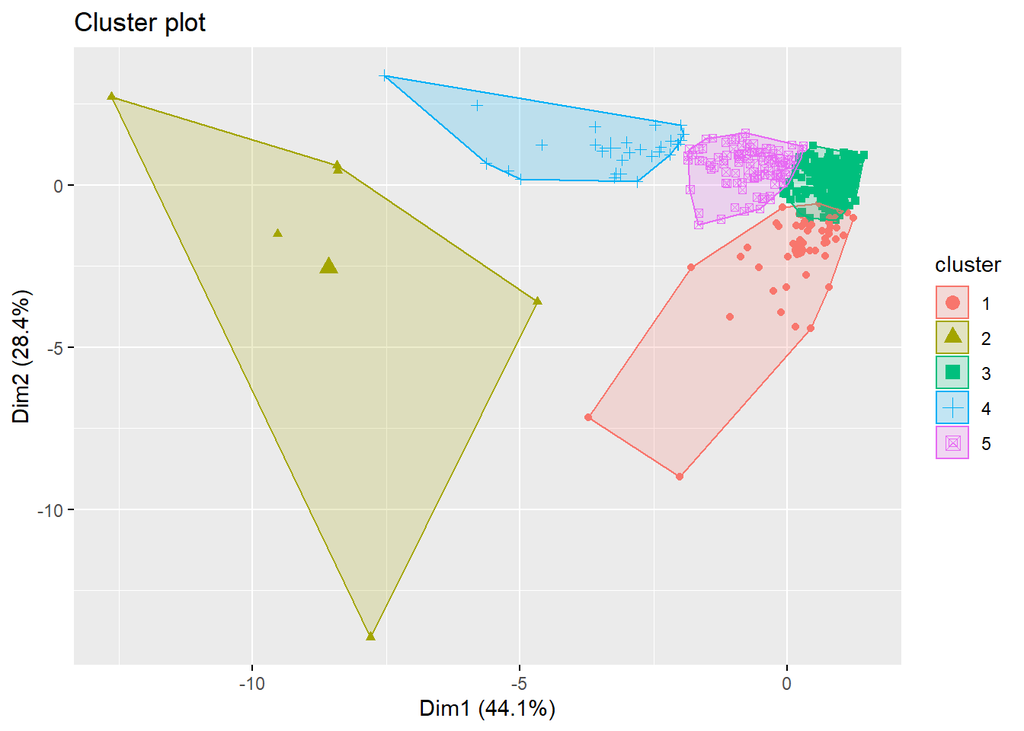

```r
set.seed(1)

wholesale_scaled <- scale(wholesale[,c(3:8)])

#5 Centroides utilizando k-means
kmeans_result <- kmeans(wholesale_scaled, centers = 5)

#predecir utilizando el modelo para agregar una variable nueva llamada "cluster" al conjunto de datos
wholesale$cluster <- kmeans_result$cluster

#convertir la variable nueva a un factor
wholesale$cluster <- factor(wholesale$cluster)

fviz_cluster(kmeans_result, wholesale[,c(3:8)], geom = "point")
```

6. Realice al menos 3 modelos cambiando los centroides

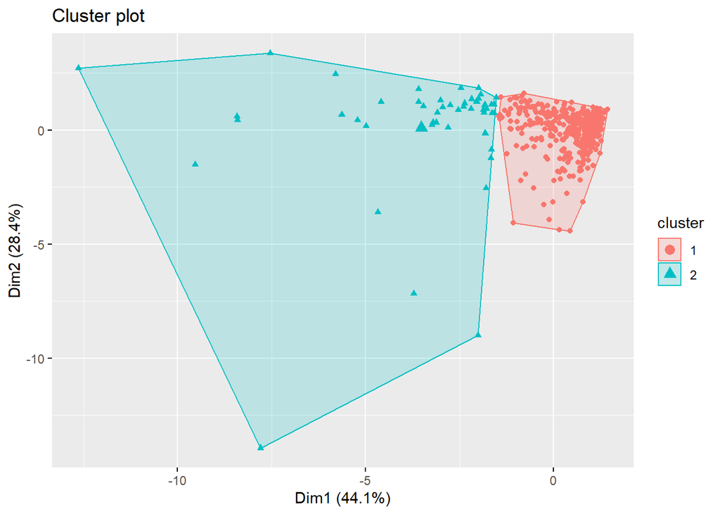

```r
set.seed(1)

# 2 Centroides utilizando k-means
kmeans_two_clusters <- kmeans(wholesale_scaled, centers = 2)
# 3 Centroides utilizando k-means
kmeans_three_clusters <- kmeans(wholesale_scaled, centers = 3)
# 4 Centroides utilizando k-means
kmeans_four_clusters <- kmeans(wholesale_scaled, centers = 4)


fviz_cluster(kmeans_two_clusters, wholesale[,c(3:8)], geom = "point")
```

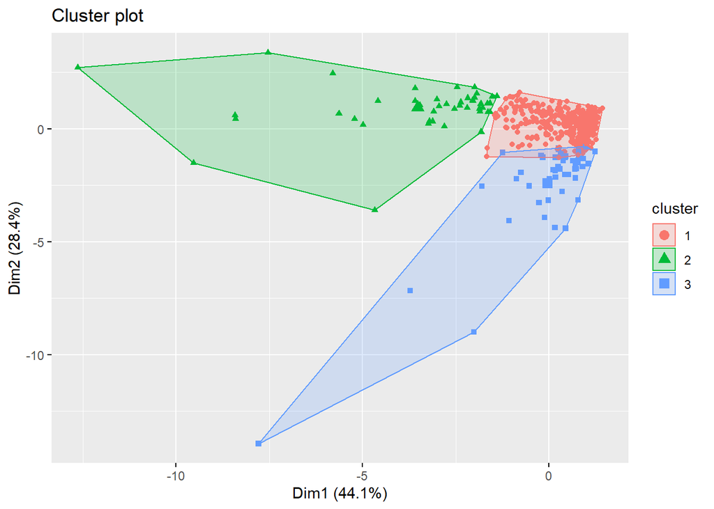

```r
fviz_cluster(kmeans_three_clusters, wholesale[,c(3:8)], geom = "point")
```

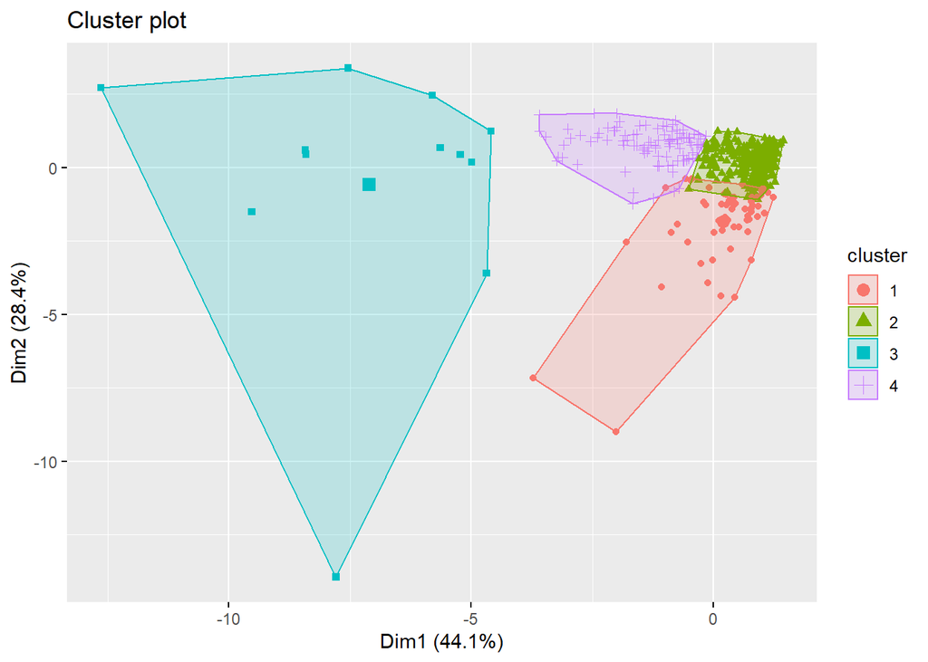

```r
fviz_cluster(kmeans_four_clusters, wholesale[,c(3:8)], geom = "point")
```

7. Evaluación del modelo

```r
by(wholesale, wholesale$cluster, summary)
```

```
## wholesale$cluster: 1
##     Channel          Region          Fresh             Milk
##  Min.   :1.000   Min.   :1.000   Min.   :  4983   Min.   :  286
##  1st Qu.:1.000   1st Qu.:3.000   1st Qu.: 23124   1st Qu.: 2218
##  Median :1.000   Median :3.000   Median : 30624   Median : 3836
##  Mean   :1.091   Mean   :2.691   Mean   : 33897   Mean   : 4931
##  3rd Qu.:1.000   3rd Qu.:3.000   3rd Qu.: 41517   3rd Qu.: 5178
##  Max.   :2.000   Max.   :3.000   Max.   :112151   Max.   :29627
##     Grocery          Frozen      Detergents_Paper   Delicassen    cluster
##  Min.   :  471   Min.   :  321   Min.   :  20.0   Min.   :    3   1:55
##  1st Qu.: 2531   1st Qu.: 3342   1st Qu.: 265.0   1st Qu.:  939   2: 0
##  Median : 4955   Median : 7368   Median : 523.0   Median : 1886   3: 0
##  Mean   : 5604   Mean   : 9181   Mean   : 832.2   Mean   : 2613   4: 0
##  3rd Qu.: 7262   3rd Qu.:11490   3rd Qu.:1066.5   3rd Qu.: 2884   5: 0
##  Max.   :21042   Max.   :60869   Max.   :4948.0   Max.   :14472
## --------------------------------------------------------
## wholesale$cluster: 2
##     Channel          Region      Fresh            Milk
##  Min.   :1.000   Min.   :3   Min.   :16117   Min.   :36423
##  1st Qu.:2.000   1st Qu.:3   1st Qu.:23787   1st Qu.:39764
##  Median :2.000   Median :3   Median :31158   Median :45074
##  Mean   :1.833   Mean   :3   Mean   :30445   Mean   :48783
##  3rd Qu.:2.000   3rd Qu.:3   3rd Qu.:36621   3rd Qu.:52244
##  Max.   :2.000   Max.   :3   Max.   :44466   Max.   :73498
##     Grocery          Frozen      Detergents_Paper   Delicassen    cluster
##  Min.   :20170   Min.   :  987   Min.   :  239    Min.   :  903   1:0
##  1st Qu.:24543   1st Qu.: 1583   1st Qu.: 8270    1st Qu.: 2249   2:6
##  Median :43843   Median : 4204   Median :22121    Median : 4704   3:0
##  Mean   :47042   Mean   : 9123   Mean   :19391    Mean   :12799   4:0
##  3rd Qu.:58591   3rd Qu.: 7125   3rd Qu.:26069    3rd Qu.:14008   5:0
##  Max.   :92780   Max.   :36534   Max.   :40827    Max.   :47943
## --------------------------------------------------------
## wholesale$cluster: 3
##     Channel          Region         Fresh            Milk
##  Min.   :1.000   Min.   :1.00   Min.   :    3   Min.   :   55
##  1st Qu.:1.000   1st Qu.:2.00   1st Qu.: 3521   1st Qu.: 1095
##  Median :1.000   Median :3.00   Median : 8607   Median : 1895
##  Mean   :1.075   Mean   :2.49   Mean   : 9677   Mean   : 2460
##  3rd Qu.:1.000   3rd Qu.:3.00   3rd Qu.:14276   3rd Qu.: 3328
##  Max.   :2.000   Max.   :3.00   Max.   :31812   Max.   :11006
```

[output cut: 38 more lines]

```
##  Max.   :2.000   Max.   :3.000   Max.   :31714   Max.   :23527
##     Grocery          Frozen        Detergents_Paper   Delicassen
##  Min.   : 1660   Min.   :   25.0   Min.   :  241    Min.   :   3.0
##  1st Qu.: 9580   1st Qu.:  370.0   1st Qu.: 3493    1st Qu.: 553.5
##  Median :11610   Median :  935.5   Median : 4620    Median :1354.5
##  Mean   :12403   Mean   : 1488.4   Mean   : 4892    Mean   :1533.4
##  3rd Qu.:14878   3rd Qu.: 2125.5   3rd Qu.: 6737    3rd Qu.:2093.5
##  Max.   :28986   Max.   :10155.0   Max.   :10069    Max.   :7844.0
##  cluster
##  1:  0
##  2:  0
##  3:  0
##  4:  0
##  5:110
##
```

Por cada uno de los grupos generados podemos ver las estadísticas descriptivas por cada una de las categorías de los productos, valores mínimos, máximos, media, además del total de clientes dentro de cada grupo. Se reafirman características que ya vieron al graficar el modelo **kmeans_result**, como por ejemplo que el cluster 2 posee la menor cantidad de observaciones y el cluster 3, la mayor.

8. Desarolle al menos 5 conclusiones sobre los grupos realizados

Observaciones de los canales por cluster

```r
table(wholesale$Channel, kmeans_result$cluster)
```

```
##
##       1   2   3   4   5
##   1  50   1 223   0  24
##   2   5   5  18  28  86
```

Observaciones de las regiones por cluster

```r
table(wholesale$Region, kmeans_result$cluster)
```

```
##
##       1   2   3   4   5
##   1   7   0  47   7  16
##   2   3   0  29   5  10
##   3  45   6 165  16  84
```

Gasto total de productos frescos por cluster:

```r
wholesale %>%
  group_by(cluster) %>%
  summarise(Fresh = sum(Fresh))
```

```
## # A tibble: 5 x 2
##   cluster   Fresh
##   <fct>     <int>
## 1 1       1864340
## 2 2        182670
## 3 3       2332159
## 4 4        160485
## 5 5        740477
```

Gasto total de leche por cluster:

```r
wholesale %>%
  group_by(cluster) %>%
  summarise(Milk = sum(Milk))
```

```
## # A tibble: 5 x 2
##   cluster   Milk
##   <fct>    <int>
## 1 1       271196
## 2 2       292696
## 3 3       592891
## 4 4       450120
## 5 5       943454
```

Gasto total de comestibles por cluster:

```r
wholesale %>%
  group_by(cluster) %>%
  summarise(Grocery = sum(Grocery))
```

```
## # A tibble: 5 x 2
##   cluster Grocery
##   <fct>     <int>
## 1 1        308231
## 2 2        282252
## 3 3        756036
## 4 4        787678
## 5 5       1364365
```

Gasto total de productos congelados por cluster:

```r
wholesale %>%
  group_by(cluster) %>%
  summarise(Frozen = sum(Frozen))
```

```
## # A tibble: 5 x 2
##   cluster Frozen
##   <fct>    <int>
## 1 1       504982
## 2 2        54737
## 3 3       581688
## 4 4        46522
## 5 5       163721
```

Gasto total de detergente y papel por cluster:

```r
wholesale %>%
  group_by(cluster) %>%
  summarise(Detergents_Paper = sum(Detergents_Paper))
```

```
## # A tibble: 5 x 2
##   cluster Detergents_Paper
##   <fct>              <int>
## 1 1                  45772
## 2 2                 116345
## 3 3                 167626
## 4 4                 400023
## 5 5                 538091
```

Gasto total de Delicassen por cluster:

```r
wholesale %>%
  group_by(cluster) %>%
  summarise(Delicassen = sum(Delicassen))
```

```
## # A tibble: 5 x 2
##   cluster Delicassen
##   <fct>        <int>
## 1 1           143736
## 2 2            76795
## 3 3           223572
## 4 4            58171
## 5 5           168669
```

# Principales características por grupo:

#### Grupo #1: (Tercer grupo más pequeño)

- Principales observaciones en el canal 1 y la región 3
- Posee el cliente con el mayor consumo de productos en la categoría “Fresh”
- Menor consumo de leche entre todos los grupos
- Bajo consumo de comestibles
- Bajo consumo de detergentes y papel

#### Grupo #2: (Grupo más pequeño)

- Principales observaciones en el canal 2 y la región 3
- Posee las observaciones más distantes entre si
- Posee el cliente con el mayor consumo de leche
- Bajo consumo de productos frescos
- Bajo consumo de leche

#### Grupo #3: (Grupo más grande)

- Principales observaciones en el canal 1 y la región 3
- Posee el cliente con el menor consumo de detergente y papel
- Mayor consumo de productos frescos entre todos los grupos
- Alto consumo de comestibles
- Mayor consumo de productos congelados

#### Grupo #4: (Segundo grupo más pequeño)

- Principales observaciones en el canal 2 y la región 3
- Bajo consumo de productos frescos
- Alto consumo de comestibles
- Menor consumo de productos congelados entre todos los grupos
- Alto consumo de detergentes y papel

#### Grupo #5: (Segundo grupo más grande)

- Principales observaciones en el canal 2 y la región 3
- Mayor consumo de leche entre todos los grupos
- Mayor consumo de comestibles entre todos los grupos
- Mayor consumo de detergentes y papel entre todos los grupos
- Alto consumo de Delicassen